# Anomaly_Detection

## Anomaly Detection

#### Outlier Detection, unsupervised anomaly detection

- The training data contains outliers which are defined as observations that are far from the others. Outlier detection estimators thus try to fit the regions where the training data is the most concentrated, ignoring the deviant observations
- The outliers/anomalies cannot form a dense cluster as available estimators assume that the outliers/anomalies are located in low density regions

#### Novelty Detection, semi-supervised anomaly detection

- The training data is not polluted by outliers and we are interested in detecting whether a new observation is an outlier. In this context an outlier is also called a novelty
- The novelties/anomalies can form a dense cluster as long as they are in a low density region of the training data, considered as normal in this context

#### 1. Outlier Detection

- Don’t have a clean data set representing the population of regular observations
- Can use trained model to evaluate the training dataset

```python
import numpy as np
m1 = np.random.normal(size=1000)
m2 = np.random.normal(scale=0.5, size=1000)
X = np.vstack([m1.ravel(), m2.ravel()]).T
X_test = np.array([[-3, 1], [0, 0]])
```

```python
import warnings
warnings.filterwarnings('ignore')
```

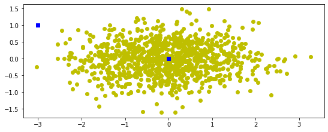

```python
import matplotlib.pyplot as plt
plt.figure(figsize=(9, 3.5))

plt.plot(X[:, 0], X[:, 1], "yo")
plt.plot(X_test[:, 0], X_test[:, 1], "bs")
```

#### EllipticEnvelope

- covariance estimation method
- assumes the data is Gaussian and learns an ellipse
- 1 inlier, -1 outlier

```python
from sklearn.covariance import EllipticEnvelope
# contamination, control how many percentage to be outlier
clf = EllipticEnvelope(random_state=0, contamination = 0.05)
clf.fit(X)
labels = clf.predict(X)
```

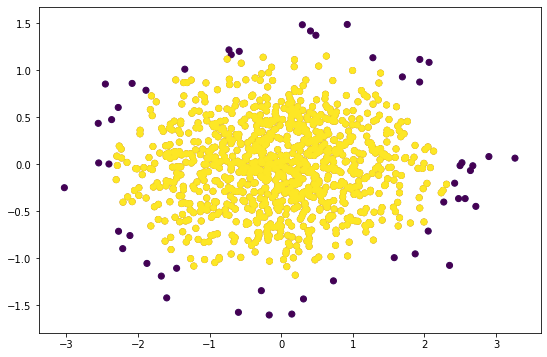

```python
import matplotlib.pyplot as plt
fig = plt.figure(figsize=(9, 6))
ax = fig.add_subplot(111)
ax.scatter(X[:, 0], X[:, 1], c=labels, marker='o', cmap="Paired")
ax.scatter(X[:, 0], X[:, 1], marker='o', c=labels)
```

#### Fast-MCD (minimum covariance determinant)

- Useful for outlier detection, in particular to clean up dataset
- Assume the normal instances are generated from a single Gaussian distribution
- Give a better estimation of the elliptic envelope

```python
from sklearn.covariance import MinCovDet
clf = MinCovDet(random_state=0)
clf.fit(X)
```

```
MinCovDet(assume_centered=False, random_state=0, store_precision=True,
          support_fraction=None)
```

```python
contamination = 4 # 4% of the the samples are outliers
threshold = np.percentile(clf.dist_, 100-contamination)
anomalies = X[clf.dist_ > threshold]
```

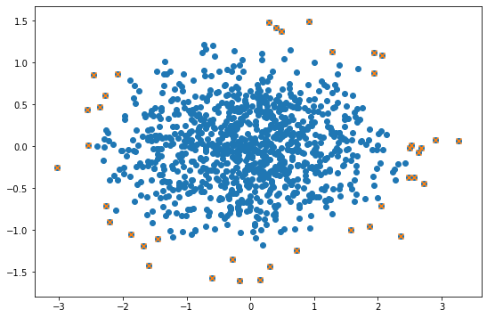

```python
fig = plt.figure(figsize=(9, 6))
ax = fig.add_subplot(111)
ax.scatter(X[:, 0], X[:, 1])
ax.scatter(anomalies[:, 0], anomalies[:, 1], marker='x')
```

#### PCA

- Use inverse_tranform() to convert the reduced features to original dimension
- Compare inversed data and the original data
- Outliers have larger reconstruction errors

#### Isolation Forest

- Efficient, especially in high-dimensional datasets
- Path length, averaged over a forest of such random trees, is a measure of normality and our decision function
- Shorter paths for anomalies, higher likely to be anomalies
- Steps
  - Build a Random Forest
  - Each Decision Tree is grown randomly, at each node picks a feature randomly, then pick a random threhold value between min and max values
  - Dataset gradually get chopped into pieces until all instances end up isolated from other instances

```python
from sklearn.ensemble import IsolationForest
# contamination, control how many percentage to be outlier
clf = IsolationForest(n_estimators=100, warm_start=True, contamination = 0.05)
clf.fit(X)
labels = clf.predict(X)
```

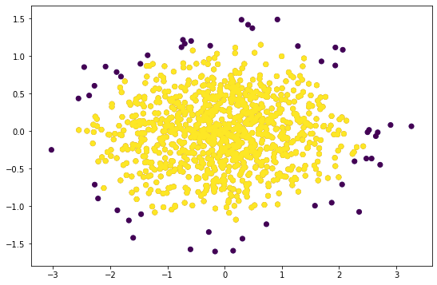

```python
fig = plt.figure(figsize=(9, 6))
ax = fig.add_subplot(111)
ax.scatter(X[:, 0], X[:, 1], c=labels, marker='o', cmap="Paired")
ax.scatter(X[:, 0], X[:, 1], marker='o', c=labels)
```

#### Local Outlier Factor

- Compare the density of instances around a given instance to the density around its neighbors
- Locality is given by k-nearest neighbors, whose distance is used to estimate the local density
- Samples that have a substantially lower density than their neighbors considered outliers

```python
from sklearn.neighbors import LocalOutlierFactor
# contamination, control how many percentage to be outlier
lof = LocalOutlierFactor(novelty=False, n_neighbors=10, contamination = 0.05)
labels = lof.fit_predict(X)
```

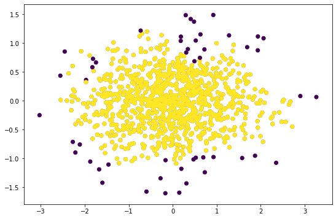

```python
fig = plt.figure(figsize=(9, 6))
ax = fig.add_subplot(111)
ax.scatter(X[:, 0], X[:, 1], c=labels, marker='o', cmap="Paired")
ax.scatter(X[:, 0], X[:, 1], marker='o', c=labels)
```

#### 2. Novelty Detection

- Need a clean data set representing the population of regular observations
- Cannot use trained model to evaluate the training datase

#### One-class SVM

- Have one class of instances, try to separate the instances in high-dimensional space from the origin
- Not scale to large datasets

```python
from sklearn.svm import OneClassSVM
clf = OneClassSVM(gamma='auto').fit(X)
labels = clf.predict(X_test)
```

```python
labels, X_test
```

```
(array([-1,  1]),
 array([[-3,  1],
        [ 0,  0]]))
```

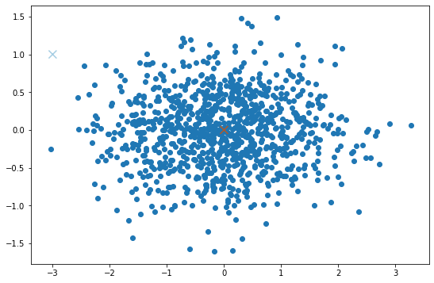

```python
fig = plt.figure(figsize=(9, 6))
ax = fig.add_subplot(111)

ax.scatter(X[:, 0], X[:, 1])
ax.scatter(X_test[:, 0], X_test[:, 1], c=labels, marker='x', s=100, cmap="Paired")
```

#### Local Outlier Factor

```python
from sklearn.neighbors import LocalOutlierFactor
lof = LocalOutlierFactor(novelty=True)
lof.fit(X)
lables = lof.predict(X_test)
```

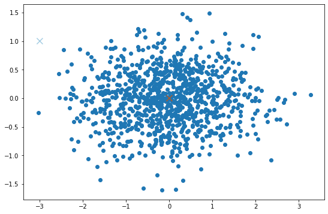

```python
fig = plt.figure(figsize=(9, 6))
ax = fig.add_subplot(111)

ax.scatter(X[:, 0], X[:, 1])
ax.scatter(X_test[:, 0], X_test[:, 1], c=labels, marker='x', s=100, cmap="Paired")
```